# Final Project

Vivian Kong

5/17/2018

```r
library("e1071")
library("ggplot2")
library("hexbin")
library("RColorBrewer")
library("psych")
houseprice <- read.csv("https://raw.githubusercontent.com/xkong100/DATA_605/master/final_project/train.csv", stringsAsFactors = FALSE, check.names = FALSE, na.strings = c("", "NA"))
skewness(houseprice$LotArea)
```

```
## [1] 12.18262
```

positive skewness means the distribution for Lot Area is skewed right. It is necessary because when we run the Chi-Square Test, it requires that the distribution of the data has to be skewed right.

```r
X <- houseprice$LotArea
Y <- houseprice$SalePrice
summary (X)
```

```
##    Min. 1st Qu.  Median    Mean 3rd Qu.    Max.
##    1300    7554    9478   10520   11600  215200
```

```r
summary(Y)
```

```
##    Min. 1st Qu.  Median    Mean 3rd Qu.    Max.
##   34900  130000  163000  180900  214000  755000
```

## Probability

Calculate as a minimum the below probabilities a through c. Assume the small letter “x” is estimated as the 1st quartile of the X variable, and the small letter “y” is estimated as the 1st quartile of the Y variable. Interpret the meaning of all probabilities. In addition, make a table of counts as shown below.

```r
x <- 7554
y <- 130000

# P(X>x)
P_X_g_x <- sum(X>x)/nrow(houseprice)
#P(Y>y)
P_Y_g_y <- sum(Y>y)/nrow(houseprice)
#P(X<x)
P_X_l_x <- sum(X<x)/nrow(houseprice)

# P(X>x & Y>y)

P_x_y_g_intersection <- sum (X>x & Y>y)/nrow(houseprice)


# P(X<x & Y>y)
P_x_y_l_intersection <- sum(X<x & Y>y)/nrow(houseprice)
```

1. $P(X>x|Y>y)=\frac {P(X>x, Y>y)}{P(Y>y)}=0.82$

```r
a_P <- P_x_y_g_intersection/P_Y_g_y
round(a_P,2)
```

```
## [1] 0.82
```

2. $P(X>x,Y>y)=0.61$

```r
b_P <- P_x_y_g_intersection
round(b_P,2)
```

```
## [1] 0.61
```

3. $P(X<x| Y>y)=\frac{P(X<x, Y>y)}{P(Y>y)}=0.18$

```r
c_P <-P_x_y_l_intersection/P_Y_g_y
round (c_P, 2)
```

```
## [1] 0.18
```

# Table of counts

```r
r1c1 <- sum(X<=x & Y<=y)
r1c1
```

```
## [1] 174
```

```r
r1c2 <- sum(X<=x & Y>y)
r1c2
```

```
## [1] 191
```

```r
r1c3 <- r1c1 + r1c2
r1c3
```

```
## [1] 365
```

```r
r2c1 <- sum(X>x & Y<=y)
r2c1
```

```
## [1] 202
```

```r
r2c2 <- sum(X>x & Y>y)
r2c2
```

```
## [1] 893
```

```r
r2c3 <- r2c1 +r2c2
r2c3
```

```
## [1] 1095
```

```r
r3c1 <- r1c1+r2c1
r3c1
```

```
## [1] 376
```

```r
r3c2 <- r1c2+r2c2
r3c2
```

```
## [1] 1084
```

```r
r3c3 <- r1c3 +r2c3
r3c3
```

```
## [1] 1460
```

```r
ctable<- matrix(c(174,191,365,202,893,1095,376,1084,1460),ncol=3,byrow=TRUE)
colnames(ctable) <- c("Y<=Q1","Y>Q1","total")
rownames(ctable) <- c("X<=Q1","X>Q1","total")
ctable <- as.table(ctable)
ctable
```

```
##       Y<=Q1 Y>Q1 total
## X<=Q1   174  191   365
## X>Q1    202  893  1095
## total   376 1084  1460
```

# Independence

$A=X>x$, $B=Y>y$. If A and B are independent, $P(AB)=P(A)P(B)$

```r
P_AB <-P_x_y_g_intersection
P_AB
```

```
## [1] 0.6116438
```

```r
P_A <-P_X_g_x
P_A
```

```
## [1] 0.75
```

```r
P_B <- P_Y_g_y
P_B
```

```
## [1] 0.7424658
```

```r
P <- P_A * P_B
P
```

```
## [1] 0.5568493
```

Since $P(AB)=0.62$, and $P(A)\cdot P(B)=0.56$. They are close but they are not the same which means that they are not independent. We also will use Chi-Square test to test our mathematical outcome.

```r
summary(ctable)
```

```
## Number of cases in table: 5840
## Number of factors: 2
## Test for independence of all factors:
##  Chisq = 122.27, df = 4, p-value = 1.75e-25
```

For Chi-Square Test, our $H_0$ is X and Y are independent. $H_A$ is X and Y are dependent. By the test, we get $P_{value}=1.75*10^{-25}$ It is statistical significant. The Chi-Square test also indicates that They are associated.

## Descriptive and Inferential Statistics.

# Univariate descriptive statistics for X and Y

```r
describe(X)
```

```
##    vars    n     mean      sd median trimmed     mad  min    max  range
## X1    1 1460 10516.83 9981.26 9478.5 9563.28 2962.23 1300 215245 213945
##     skew kurtosis     se
## X1 12.18   202.26 261.22
```

```r
describe(Y)
```

```
##    vars    n     mean      sd median  trimmed     mad   min    max  range
## X1    1 1460 180921.2 79442.5 163000 170783.3 56338.8 34900 755000 720100
##    skew kurtosis      se
## X1 1.88      6.5 2079.11
```

# ScatterPlot

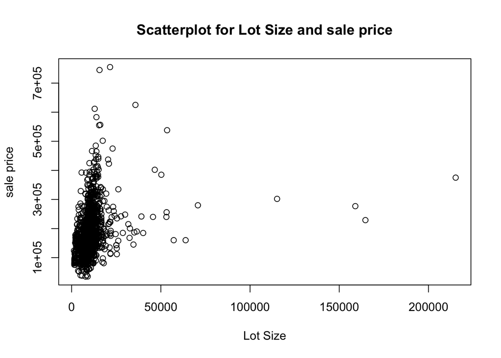

```r
plot(X,Y,main="Scatterplot for Lot Size and sale price", xlab="Lot Size", ylab="sale price" )
```

[figure not shown]

```r
L <- rnorm(20000)
S <- rnorm(20000)
bin <- hexbin(L, S,xbins=50)
colors <-colorRampPalette(rev(brewer.pal(11,'Spectral')))
plot(bin, main="Scatterplot for Lot Size and sale price",colramp=colors,legend=F, xlab="Lot Size", ylab="sale price")
```

Correlation matrix My 3 quantitative variables are TotRmsAbvGrd:Total rooms above grade, Garage Area, and OverallQua: Overall Quality

```r
mydata <- houseprice[,c(63,18,55)]
head(mydata)
```

```
##   GarageArea OverallQual TotRmsAbvGrd
## 1        548           7            8
## 2        460           6            6
## 3        608           7            6
## 4        642           7            7
## 5        836           8            9
## 6        480           5            5
```

```r
res <- cor(mydata)
round(res,2)
```

```
##              GarageArea OverallQual TotRmsAbvGrd
## GarageArea         1.00        0.56         0.34
## OverallQual        0.56        1.00         0.43
## TotRmsAbvGrd       0.34        0.43         1.00
```

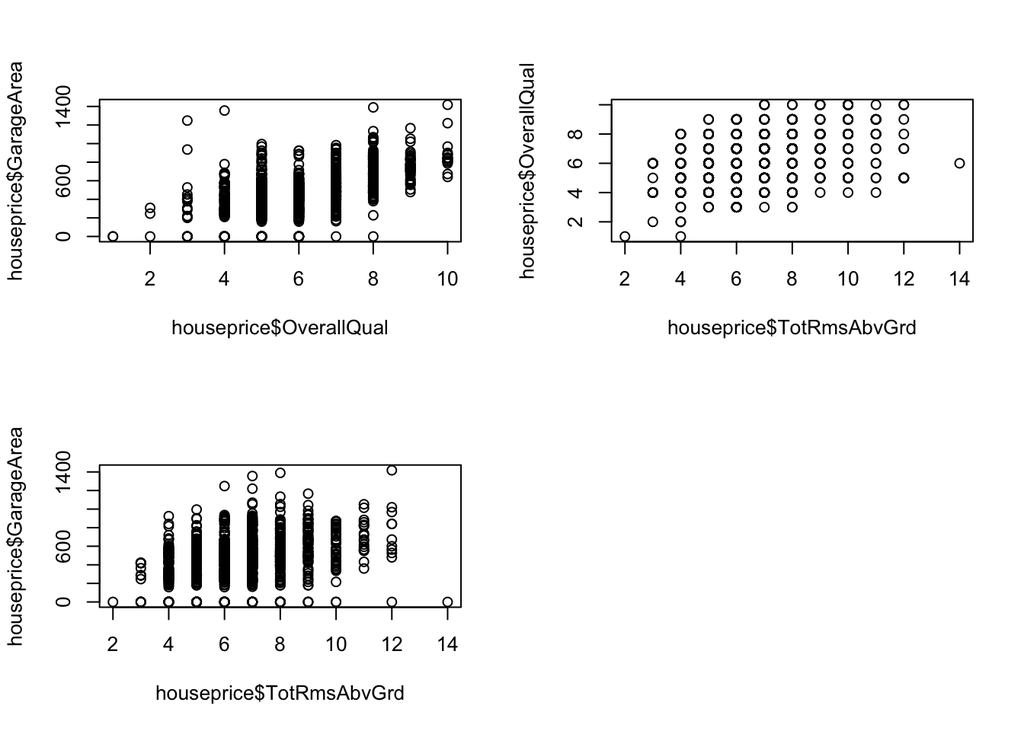

```r
par(mfrow=c(2,2))
plot(houseprice$OverallQual,houseprice$GarageArea)
plot(houseprice$TotRmsAbvGrd,houseprice$OverallQual )
plot(houseprice$TotRmsAbvGrd,houseprice$GarageArea)
```

# Correlation Test

```r
rt1 <- cor.test(houseprice$TotRmsAbvGrd,houseprice$GarageArea,method="pearson",conf.level=0.92)
rt1
```

```
##
##  Pearson's product-moment correlation
##
## data:  houseprice$TotRmsAbvGrd and houseprice$GarageArea
## t = 13.705, df = 1458, p-value < 2.2e-16
## alternative hypothesis: true correlation is not equal to 0
## 92 percent confidence interval:
##  0.2965816 0.3778050
## sample estimates:
##       cor
## 0.3378221
```

```r
rt2 <- cor.test(houseprice$OverallQual,houseprice$TotRmsAbvGrd,method="pearson",conf.level=0.92)
rt2
```

```
##
##  Pearson's product-moment correlation
##
## data:  houseprice$OverallQual and houseprice$TotRmsAbvGrd
## t = 18.054, df = 1458, p-value < 2.2e-16
## alternative hypothesis: true correlation is not equal to 0
## 92 percent confidence interval:
##  0.3892456 0.4641908
## sample estimates:
##       cor
## 0.4274523
```

```r
rt3 <- cor.test(houseprice$OverallQual,houseprice$GarageArea,method="pearson",conf.level=0.92)
rt3
```

```
##
##  Pearson's product-moment correlation
##
## data:  houseprice$OverallQual and houseprice$GarageArea
## t = 25.946, df = 1458, p-value < 2.2e-16
## alternative hypothesis: true correlation is not equal to 0
## 92 percent confidence interval:
##  0.5298372 0.5925899
## sample estimates:
##       cor
## 0.5620218
```

From the result, we can tell that for all 3 cases, there exist correlations between overall quality and Total rooms above the ground, garage area and Total Rooms above the ground, and overall quality and garage area. Since all of the p-values are extremely small and proved that the correlations between them are statistically significant. For each 92% confidence interval, it means that 1) We have 92% confidence to conclude that the true population correlation will be between 0.30 and 0.38 for total rooms above the ground and garage area. 2) We have 92% confidence to conclude that the true population correlation will be between 0.39 and 0.46 for overall quality and Total rooms above the ground. 3) We have 92% confidence to conclude that the true population correlation will be between 0.53 and 0.59 for overall quality and Garage area.

# Linear Algebra and Correlation

```r
#invert the correlation for precision
p <- solve (res)
p
```

```
##              GarageArea OverallQual TotRmsAbvGrd
## GarageArea    1.4870334  -0.7598496   -0.1775533
## OverallQual  -0.7598496   1.6118347   -0.4322885
## TotRmsAbvGrd -0.1775533  -0.4322885    1.2447642
```

```r
#precision * correlation
p %*% res
```

```
##                GarageArea   OverallQual  TotRmsAbvGrd
## GarageArea   1.000000e+00 -4.163336e-17  0.000000e+00
## OverallQual  5.551115e-17  1.000000e+00 -5.551115e-17
## TotRmsAbvGrd 0.000000e+00 -1.110223e-16  1.000000e+00
```

```r
# correlation * precision

res %*% p
```

```
##                 GarageArea   OverallQual TotRmsAbvGrd
## GarageArea    1.000000e+00  2.775558e-17            0
## OverallQual  -2.775558e-17  1.000000e+00            0
## TotRmsAbvGrd  2.775558e-17 -1.110223e-16            1
```

# Calculus-Based Probability & Statistics

```r
library("MASS")
min(X)
```

```
## [1] 1300
```

Derive the exponential distribution:

```r
fit <- fitdistr(X,"exponential")
lambda <-fit$estimate
lambda
```

```
##        rate
## 9.50857e-05
```

Create the sample of 1000

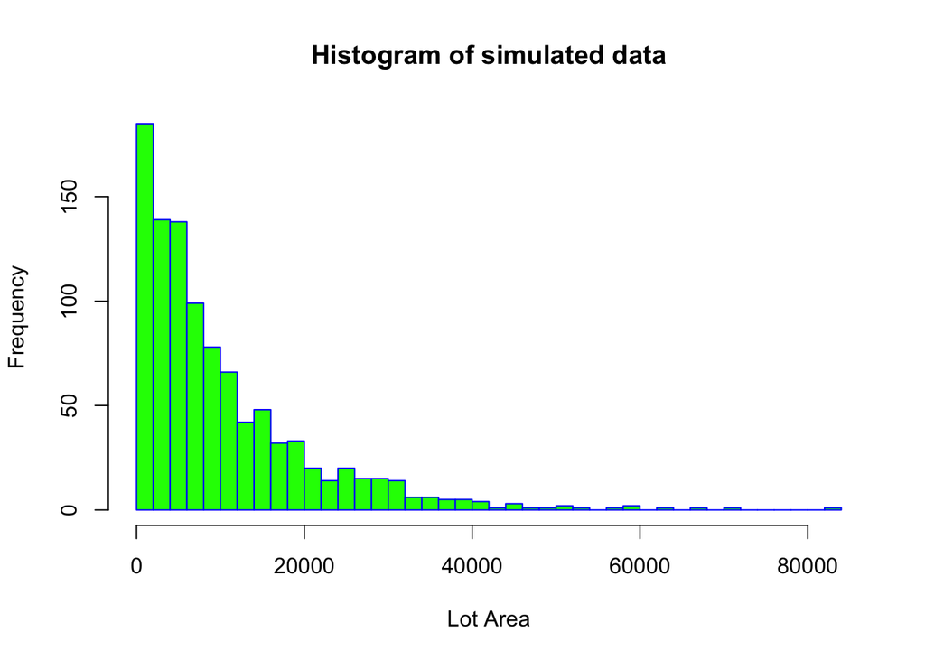

```r
sample <- rexp(1000,lambda)
hist(sample,main="Histogram of simulated data", xlab="Lot Area",border="blue", col="green",breaks=50)
```

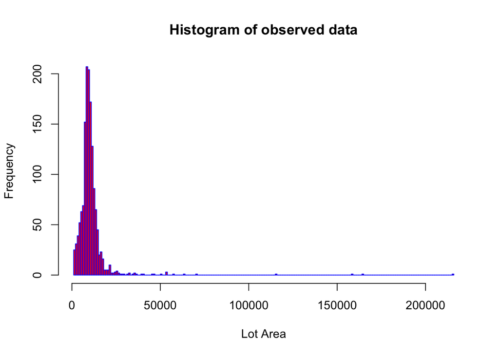

```r
hist(X,main="Histogram of observed data", xlab="Lot Area",border="blue", col="red",breaks=200)
```

Using the exponential pdf, find the 5th and 95th percentiles using the cumulative distribution function (CDF)

```r
# simulated 5th percentile
qexp(.05,rate=lambda)
```

```
## [1] 539.4428
```

```r
# observed 5th percentile
obs.p5 <- quantile(X, 0.05)
obs.p5
```

```
##     5%
## 3311.7
```

```r
# simulated 95th percentile
qexp(.95,rate=lambda)
```

```
## [1] 31505.6
```

```r
# observed 95th percentile
obs.p95<-quantile(X,0.95)
obs.p95
```

```
##      95%
## 17401.15
```

Calculated a 95% confidence interval from the empirical data.

```r
library("Rmisc")
CI(X, 0.95)
```

```
##    upper     mean    lower
## 11029.24 10516.83 10004.42
```

We have 95% confidence, the true population mean of Lot size is between 10004.42 sq feet and 11029.24 sq feet. In my opinion, the exponential distribution would not be a good fit in this case since the center of the exponential distribution is shifted left and it becomes a extreme skewed right case comparing to the empirical data.

# Modeling

Multiple Linear Regression

```r
fit <- lm(Y ~ houseprice$OverallQual + houseprice$LotArea + houseprice$TotRmsAbvGrd+houseprice$GarageArea)
summary(fit)
```

```
##
## Call:
## lm(formula = Y ~ houseprice$OverallQual + houseprice$LotArea +
##     houseprice$TotRmsAbvGrd + houseprice$GarageArea)
##
## Residuals:
##     Min      1Q  Median      3Q     Max
## -330190  -22390   -2819   17095  372817
##
## Coefficients:
##                           Estimate Std. Error t value Pr(>|t|)
## (Intercept)             -1.300e+05  5.628e+03 -23.100   <2e-16 ***
## houseprice$OverallQual   3.313e+04  1.005e+03  32.960   <2e-16 ***
## houseprice$LotArea       1.021e+00  1.126e-01   9.067   <2e-16 ***
## houseprice$TotRmsAbvGrd  9.353e+03  7.590e+02  12.323   <2e-16 ***
## houseprice$GarageArea    7.858e+01  6.293e+00  12.489   <2e-16 ***
## ---
## Signif. codes:  0 '***' 0.001 '**' 0.01 '*' 0.05 '.' 0.1 ' ' 1
##
## Residual standard error: 41790 on 1455 degrees of freedom
## Multiple R-squared:  0.724,  Adjusted R-squared:  0.7233
## F-statistic: 954.3 on 4 and 1455 DF,  p-value: < 2.2e-16
```

The multiple regression is: $SalePrice=33130\cdot OverallQual+1.021\cdot LotArea+9353\cdot TotRmsAbvGrd+78.58\cdot GarageArea-130000$ Plot

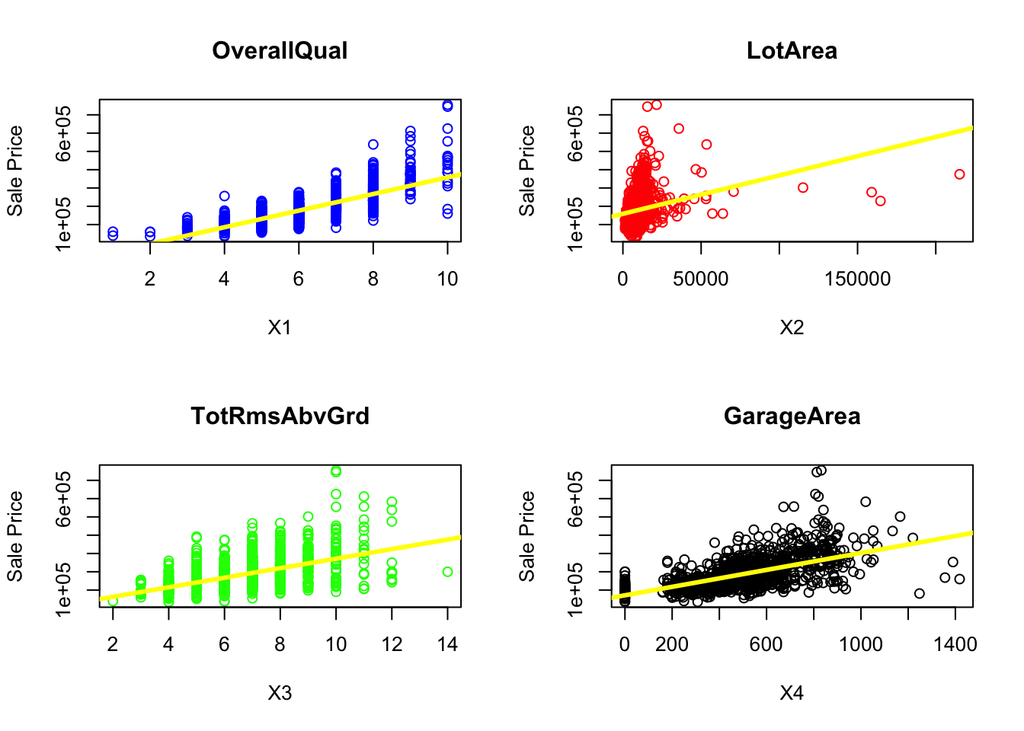

```r
par(mfrow=c(2,2))
X1<-houseprice$OverallQual
X2<-houseprice$LotArea
X3<-houseprice$TotRmsAbvGrd
X4<-houseprice$GarageArea


plot(X1,Y, col="blue", main="OverallQual", ylab="Sale Price")
abline(lm(Y~X1), col="yellow", lwd=3) # regression line (y~x)

plot(X2,Y, col="red", main="LotArea", ylab="Sale Price")
abline(lm(Y~X2), col="yellow", lwd=3) # regression line (y~x)

plot(X3,Y, col="green", main="TotRmsAbvGrd", ylab="Sale Price")
abline(lm(Y~X3), col="yellow", lwd=3) # regression line (y~x)

plot(X4,Y, col="black", main="GarageArea", ylab="Sale Price")
abline(lm(Y~X4), col="yellow", lwd=3) # regression line (y~x)
```

Load test data set and create calculated column

```r
test <- read.csv("https://raw.githubusercontent.com/xkong100/DATA_605/master/final_project/test.csv", stringsAsFactors = FALSE, check.names = FALSE, na.strings = c("", "NA"))

SalePrice <- ((33130*houseprice$OverallQual)+(1.021*houseprice$LotArea)+(9353*houseprice$TotRmsAbvGrd)+(78.58*houseprice$GarageArea)-130000)
test <-test[,c("Id","OverallQual","LotArea","TotRmsAbvGrd", "GarageArea")]
head(test)
```

```
##     Id OverallQual LotArea TotRmsAbvGrd GarageArea
## 1 1461           5   11622            5        730
## 2 1462           6   14267            6        312
## 3 1463           5   13830            6        482
## 4 1464           6    9978            7        470
## 5 1465           8    5005            5        506
## 6 1466           6   10000            7        440
```

```r
submission <-cbind(test$Id, SalePrice)
colnames(submission)[1] <- "Id"
submission[submission<0] <- median(SalePrice) #clear negatives due to missing values
submission<-as.data.frame(submission[1:1459,])
head(submission)
```

```
##     Id SalePrice
## 1 1461  228423.3
## 2 1462  170846.4
## 3 1463  217290.9
## 4 1464  227579.9
## 5 1465  299469.3
## 6 1466  134544.8
```

```r
str(submission)
```

```
## 'data.frame':    1459 obs. of  2 variables:
##  $ Id       : num  1461 1462 1463 1464 1465 ...
##  $ SalePrice: num  228423 170846 217291 227580 299469 ...
```

```r
dim(submission)
```

```
## [1] 1459    2
```

```r
write.csv(submission,file="submission.csv",quote=FALSE, row.names = FALSE)
```

On my Kaggle.com, my submission score is 0.5959.(username is xkong100).